# act_report

## Analysis Report on Weratedogs Udacity project

WeRateDogs is a twitter account that rates people's dogs with humerous content about the dogs.

This report communicate the insights and visualizations produced from the projects.

The following are some insights found:

- most common dog names
- most common dog breeds
- tweets with the highest favourite count and retweet count
- correlation between date tweet was posted, favorite_count and retweet_count

#### 1) Most common dog names tweeted about

Base on the data available, there is a total of 772 dog names for a total of 1749 tweets, of the 1749 tweets available 547 tweets didn't have a name for the dogs

the most common dog name is Cooper appearing 11 times, followed by Charlie, lucy, Oliver coming up 10 times

here is a visualization of the top 10 most common dog names

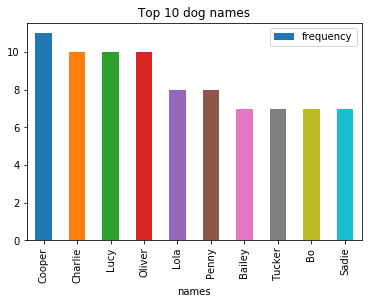

#### 2) Most common dog breeds tweeted about

There is a total of 113 breeds available in all 1749 twwets. of the 113 breeds golden retriever occured the most, appearing in over 173 tweets. below is a visualization of the top 10 most common dog breeds

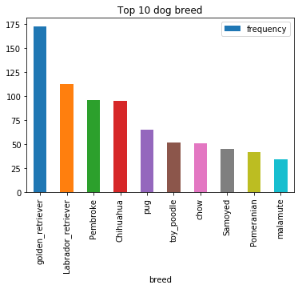

#### 3) tweets with the highest favourite count and retweet count

**tweet with highest retweet count**

The tweet with the highest retweet counts is that of a shih-Tzu breed, not very common as it isnt among the top 10 dog breeds available on this data, the tweet was posted on the 18 june 2016

**Tweet with favourite count**

The tweet with the highest favourite count is a pug, one of the most common dog breeds available and has a total of 132810 favourite counts with a tweet_id of 822872901745569793 and was posted on 21st of january 2017

#### 4) correlation between date tweet was posted, favorite_count and retweet_count

tweet with highest retweet count was posted on june 2016 and tweet with favorite count was posted on january 2017, this led me to confirm if there was a correlation between favorite count, retweet counts and time tweet was posted.

**correlation between retweet counts and time tweet was posted**

base on the regression graph below, there is no relationship between time tweet was posted and retweet counts

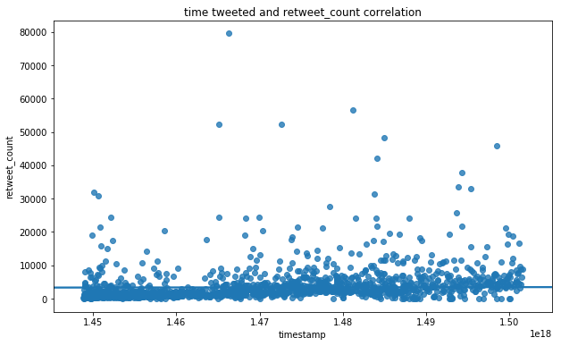

**correlation between favorite counts and time tweet was posted**

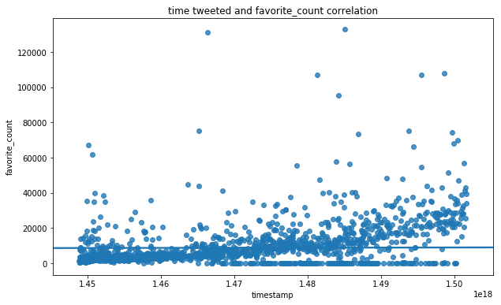